# Unsupervised Clustering and Visualization of Plant Disease Severity

Jacobo Robledo

2024-10-23

# Introduction

In this analysis, we perform an unsupervised clustering task to identify zones that are similar in terms of disease severity and other environmental variables. We utilize K-means clustering to group the data and visualize the results using heatmaps and spatial plots. This approach can help in understanding patterns in disease distribution and identifying areas that may require targeted interventions.

# Load Necessary Libraries

We start by loading the necessary libraries for data manipulation, clustering, and visualization.

```r
# Load necessary libraries
library(ggplot2)     # For data visualization
library(reshape2)    # For data reshaping
library(dplyr)       # For data manipulation
library(gridExtra)   # For arranging multiple plots
```

# Data Preparation

## Load the Dataset

We load the dataset containing environmental variables and disease severity information.

```r
# Set seed for reproducibility
set.seed(123)

# Load the dataset
data_unsupervised <- read.csv("https://raw.githubusercontent.com/jrobledob/2024_PLP6905_ML_Class/refs/heads/main/data_unsupervised.csv")

# View the first few rows
head(data_unsupervised)
```

```
##    latitude  longitude Temperature Humidity SoilMoisture BacteriaCount
## 1 -38.23605  -52.70181    21.99054 41.17718     85.35317        999179
## 2  51.89492  -48.08108    20.03151 40.11611     66.60066       1000321
## 3 -16.38415  -76.64395    30.13393 40.44263     73.33267       1000410
## 4  68.94313 -151.20975    28.75531 66.01040     31.47403        999989
## 5  79.28411  -48.43646    17.45417 64.49791     66.77179       1002127
## 6 -81.79983 -115.91503    24.52426 73.14399     46.38867       1000366
##   FungiCount  Severity
## 1     100064 0.3991891
## 2      99919 0.4382117
## 3      99866 0.4406954
## 4     100332 0.5334093
## 5      99971 0.6918165
## 6      99947 0.4741399
```

The dataset includes variables such as:

- **Temperature**
- **Humidity**
- **SoilMoisture**
- **BacteriaCount**
- **FungiCount**
- **Severity**

These variables will be used for clustering.

# Data Preprocessing

## Select Variables for Clustering

We select the relevant variables for clustering.

```r
# Select variables for clustering
clustering_vars <- data_unsupervised %>%
  select(Temperature, Humidity, SoilMoisture, BacteriaCount, FungiCount, Severity)
```

## Standardize the Variables

Standardizing the variables ensures that each variable contributes equally to the clustering process.

```r
# Standardize the variables
clustering_vars_scaled <- scale(clustering_vars)
```

# Determine Optimal Number of Clusters

We use the Elbow Method to determine the optimal number of clusters for K-means clustering.

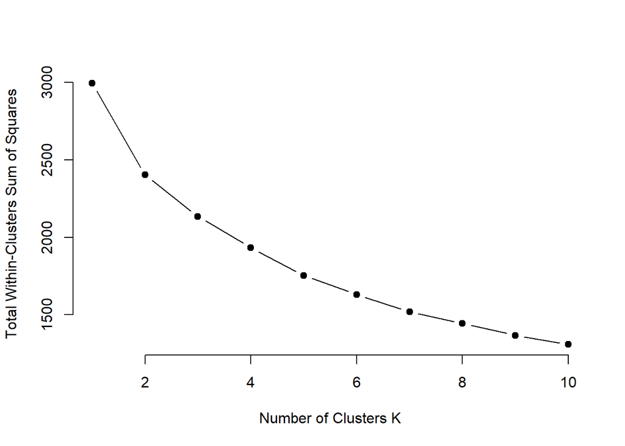

```r
# Determine the optimal number of clusters using the Elbow Method
wss <- (nrow(clustering_vars_scaled) - 1) * sum(apply(clustering_vars_scaled, 2, var))
for (i in 2:10) {
  set.seed(123)
  wss[i] <- sum(kmeans(clustering_vars_scaled, centers = i, nstart = 25)$withinss)
}

# Plot the Elbow Curve
plot(1:10, wss, type = "b", pch = 19, frame = FALSE,
     xlab = "Number of Clusters K",
     ylab = "Total Within-Clusters Sum of Squares")
```

**Explanation:**

- **Within-Cluster Sum of Squares (WSS):** Measures the compactness of the clustering.
- **Elbow Method:** We plot WSS against the number of clusters and look for an “elbow” point where the rate of decrease sharply changes, indicating the optimal number of clusters.

*Assuming the elbow point is at K = 4, we proceed with 4 clusters.*

```r
# Choose the number of clusters based on the Elbow Method
k <- 4

# Perform K-means clustering
set.seed(123)
kmeans_result <- kmeans(clustering_vars_scaled, centers = k, nstart = 25)

# Add cluster assignments to the data frame
data_unsupervised$Cluster <- as.factor(kmeans_result$cluster)
```

# Data Visualization

## Plot Clusters on the Map

We plot the clusters on a map, with points colored by cluster and sized by disease severity.

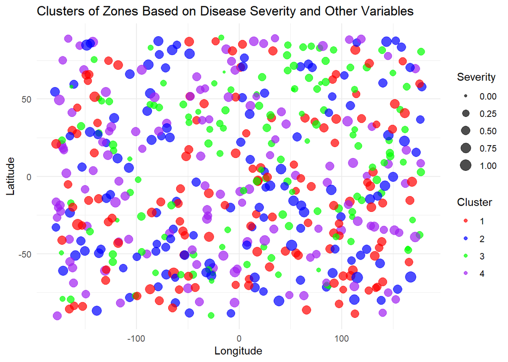

```r
# Plot the clusters on the map
ggplot(data_unsupervised, aes(x = longitude, y = latitude)) +
  geom_point(aes(color = Cluster, size = Severity), alpha = 0.7) +
  scale_color_manual(values = c("red", "blue", "green", "purple")) +
  scale_size(range = c(1, 5)) +
  theme_minimal() +
  labs(title = "Clusters of Zones Based on Disease Severity and Other Variables",
       x = "Longitude",
       y = "Latitude",
       color = "Cluster",
       size = "Severity") +
  theme(legend.position = "right")
```

**Interpretation:**

- Each point represents a zone.
- **Color:** Indicates the cluster assignment.
- **Size:** Represents the severity of the disease.
- This plot helps visualize the spatial distribution of clusters and severity.

# Creating a Heatmap of Disease Severity

We create a heatmap to visualize the spatial distribution of disease severity.

## Install and Load Required Package

```r
# Install and load the required package for interpolation
if (!require("akima")) {
  install.packages("akima")
  library(akima)
}
```

## Interpolate Severity over the Grid

We interpolate the severity values over a grid to create a smooth heatmap.

```r
# Interpolate the severity over the grid
interp_result <- with(data_unsupervised, interp(x = longitude, y = latitude, z = Severity, duplicate = "mean"))

# Convert the interpolation result to a data frame
interp_df <- data.frame(
  longitude = rep(interp_result$x, times = length(interp_result$y)),
  latitude = rep(interp_result$y, each = length(interp_result$x)),
  Severity = as.vector(interp_result$z)
)
```

## Plot the Heatmap

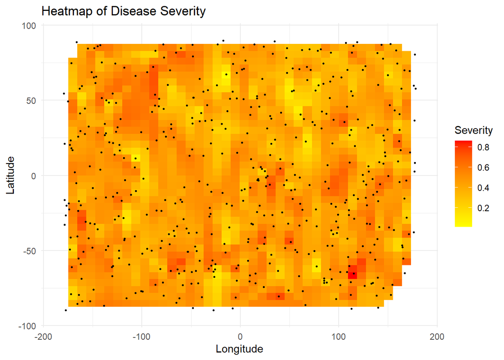

```r
# Plot the heatmap
ggplot() +
  geom_tile(data = interp_df, aes(x = longitude, y = latitude, fill = Severity)) +
  scale_fill_gradient(low = "yellow", high = "red", na.value = NA) +
  geom_point(data = data_unsupervised, aes(x = longitude, y = latitude), color = "black", size = 0.5) +
  theme_minimal() +
  labs(title = "Heatmap of Disease Severity",
       x = "Longitude",
       y = "Latitude",
       fill = "Severity")
```

**Explanation:**

- **Heatmap Tiles:** Represent interpolated severity values.
- **Color Gradient:** Ranges from yellow (low severity) to red (high severity).
- **Points:** Original data points for reference.

# Combining Heatmap with Clusters

We overlay the cluster assignments onto the heatmap to observe the relationship between clusters and severity.

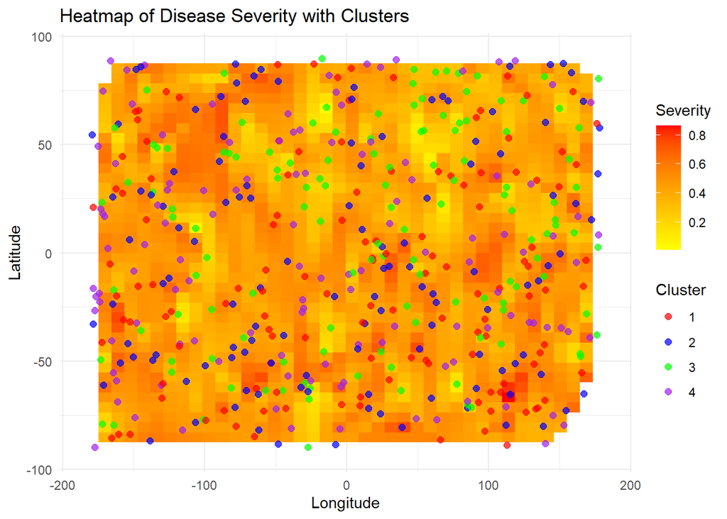

```r
# Plot the heatmap with clusters
ggplot() +
  geom_tile(data = interp_df, aes(x = longitude, y = latitude, fill = Severity)) +
  scale_fill_gradient(low = "yellow", high = "red", na.value = NA) +
  geom_point(data = data_unsupervised, aes(x = longitude, y = latitude, color = Cluster), size = 2, alpha = 0.7) +
  scale_color_manual(values = c("red", "blue", "green", "purple")) +
  theme_minimal() +
  labs(title = "Heatmap of Disease Severity with Clusters",
       x = "Longitude",
       y = "Latitude",
       fill = "Severity",
       color = "Cluster") +
  theme(legend.position = "right")
```

**Interpretation:**

- The overlay allows us to see how clusters correspond to areas of different severity levels.
- This visualization helps in identifying patterns and relationships between clusters and disease severity.

# Conclusion

In this analysis, we successfully:

- Performed K-means clustering on environmental variables and disease severity.
- Determined the optimal number of clusters using the Elbow Method.
- Visualized the clusters on a spatial map.
- Created heatmaps to display the spatial distribution of disease severity.
- Combined the heatmap with cluster assignments to observe relationships.

This unsupervised approach provides insights into the patterns of disease spread and can aid in making informed decisions for disease management.